# R Notebook

```r
library(tidyverse)
library(infer)

data("msleep")

view(msleep)
```

Question 2. Jabberwockies sleep for around 7 hours a night, on average. Perform an appropriate statistical test to determine whether the mean sleep_total in the sampled population of animal types differs from the typical value for jabberwockies.

alpha level :0.05 H0 : mean_sleep_total = mean_sleep_jabberwockies HA : mean_sleep_total != mean_sleep_jabberwockies

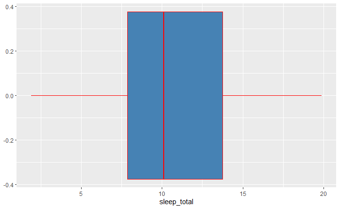

```r
#visualize the sleep_total - average is close to 10h
msleep %>%
  ggplot(aes(x = sleep_total)) +
  geom_boxplot(col = "red", fill = 'steel blue')
```

```r
#calculate average sleep.

observed_stat_total <-  msleep %>%
  summarise(mean_sleep_total = mean(sleep_total))

observed_stat_total #10.43373
```

| mean_sleep_total |
| --- |
| 10.43373 |

```r
#null distribution

null_distribution_total_sleep <-  msleep %>%
  specify(response = sleep_total) %>%
  hypothesise(null= 'point', mu = 7) %>%
  generate(resps= 1000, type = 'bootstrap') %>%
  calculate(stat = 'mean')

null_distribution_total_sleep   # stat 6.953012
```

```
Response: sleep_total (numeric)
Null Hypothesis: point
```

| stat |
| --- |
| 6.69759 |

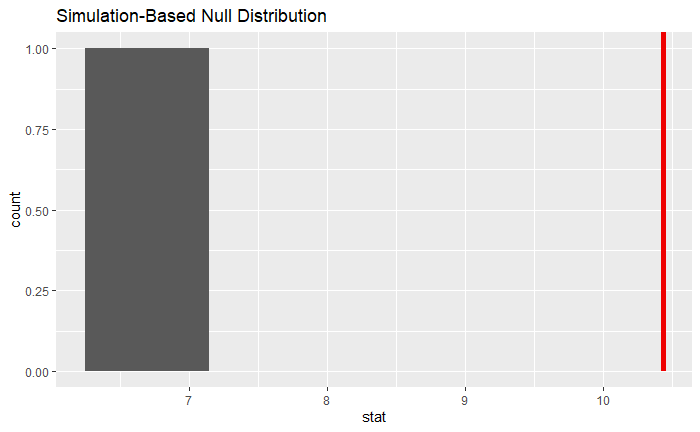

```r
# overlay visual  and direction. From my previous visualization -on top-I concluded that the direction have to be 'greater/rigth'

null_distribution_total_sleep %>%
  visualise(bins = 30)+
  shade_p_value(obs_stat =observed_stat_total$mean_sleep_total,
                direction = 'right')
```

```r
#p_value
null_distribution_total_sleep %>%
get_p_value(obs_stat = observed_stat_total$mean_sleep_total,
                direction = 'right')
```

| p_value |
| --- |
| 0 |

```r
# p_value is 0, I did wrong is 1 if I changed to less but I think I did correctly
```

```
Question 3.
```

Perform an appropriate statistical test to determine whether omnivores sleep for significantly longer than herbivores, on average.

# two independent samples, average = mean will be compare

alpha : 0.05 HO :avg_sleep_omnivores - avg_sleep_herbivores > 0 HA :avg_sleep_omnivores - avg_sleep_herbivores = 0

```r
herbi_omni <- msleep %>%
  select(name,vore,sleep_total) %>%
  filter(vore == c ('herbi','omni'))
herbi_omni
```

| name | vore | sleep_total |
| --- | --- | --- |
| Owl monkey | omni | 17.0 |
| Mountain beaver | herbi | 14.4 |
| Greater short-tailed shrew | omni | 14.9 |
| Cow | herbi | 4.0 |
| Goat | herbi | 5.3 |
| African giant pouched rat | omni | 8.3 |
| Tree hyrax | herbi | 5.3 |
| North American Opossum | omni | 18.0 |
| Asian elephant | herbi | 3.9 |
| Horse | herbi | 2.9 |

[output cut: 18 more lines]

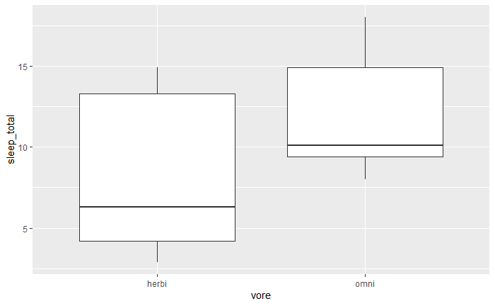

```r
#Visual , looks like that in avg omni sleep more than herbi
herbi_omni %>%
  ggplot(aes(x = vore, y = sleep_total))+
  geom_boxplot()
```

[output not shown]

```r
observed_stat_compa  #stat -3.221538
```

```
Response: sleep_total (numeric)
Explanatory: vore (factor)
```

| stat |
| --- |
| -3.221538 |

```r
null_distribution_compa
```

```
Response: sleep_total (numeric)
Explanatory: vore (factor)
Null Hypothesis: independence
```

| replicate | stat |
| --- | --- |
| 1 | 1.201025641 |
| 2 | -0.148717949 |
| 3 | -0.823589744 |
| 4 | -1.613333333 |
| 5 | -0.062564103 |
| 6 | 1.387692308 |
| 7 | 0.612307692 |
| 8 | 0.195897436 |
| 9 | 0.540512821 |
| 10 | -2.403076923 |

[output cut: 990 more lines]

[figure not shown]

[output not shown]

alpaha ; 0.05 H0 :prop_domesticated -0.05 = 0 HA : prop_domesticated -0.05 !=0

[output not shown]

[output not shown]

1.2 Hypothesis testing - Defining the Hypothesis

Question 1.

Question 2.

Question 3.

1.3 Hypothesis Testing - Interpreting the results

```
Question 1.
Coffee shop problem. Significance level: 0.05, calculated p-value: 0.07
```

With a p_value slightly superior to our significant level, we can not reject the null hypothesis about if the Coffee shop has problems

```
Question 2.
Website company problem. Significance level: 0.01, p-value: 0.006
```

In this case, our p-value is less than our significant level, so we can reject the null hypothesis about the problems around the website company.

```
Question 3.
Manufacturing company problem. Significance level: 0.05, p-value: 0.55
```

With a P-value superior to to our significant level, we fail to reject the null hypothesis about the problems around the manufacturing company